# Leaving My Body - How and What Happens - A Quantum Physics Connection

*There are similarities that I’ve heard from others but this is how I experience this ability and what aspect of quantum physics it may be connected to.*

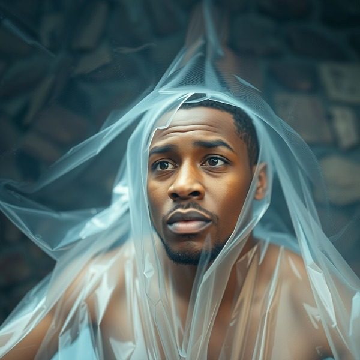

There are different gifts of people who can cross through or over the extents of the universe that we experience through our human senses. Many years ago, I had a friend/ co-worker who could do things that I could not. We worked together for a few months. One day when having lunch in the small lounge, we bonded over activities that were out of the norm of what most people talk about in general conversation. I told him of my ability to ‘travel’ as I call it, and he told me of his ability to move objects with his mind. He offered to show me right then and there.

We were alone in the lounge. There were other co-worker’s handbags and things hanging on a coat rack across from where we were sitting. He got quiet and proceeded to demonstrate. He said to watch a specific handbag that he pointed out. I did so and before one minute had passed, the handbag began to swing; slightly at the beginning and then with far more gusto. During the event he got a little nervous at how well it was going, maybe it was the astonishment on my face that caused his emotional shift. I couldn’t believe what I was seeing as his self-consciousness washed over him. Just at that moment when his demeanor changed, the bag stopped moving. I assured him that I was OK with it but that was a big lie. I was a stunned actually. I got up to control as many variables as I could. I made sure the door was shut which ruled out any outside air gusts affecting the bag. I then closed the HVAC vents. I visually inspected and touched the handbag. It was heavy with one lady co-worker’s belongings. I concluded that it was my friend moving the bag telekinetically. I asked him to do it again. After a minute or so, it began swinging with a good arc of at least 10 degrees in either direction. We were real buds after that.

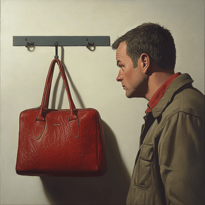

I told him about my night ‘travels’ and some of the things I experienced. He was equally intrigued. Before our break was over we had agreed to try to meet together inside a travelling co-event at bedtime. We synched our going to bed times and confirmed it by a phone call at the outset. We tried for many nights much to the chagrin of his wife, but no luck. We discussed our experiences and our attempts, and concluded it’s got to be about the gifts you have been given and the depth of the gift within you. In my perspective, it’s also about developing those gifts.

I am more keen on the concept of practice because as a kid, for whatever reason, I was fascinated by anyone who could wiggle their ears. Supposedly only 10-20% of humans can do this. It involves the auricular muscles that are vestigialin modern humans. Via a lot of tentation, I practiced trying to find the muscles in my head that would enable ear wiggling until I found the correct route. Once known, I can’t now unknow it. Significant things are like that. I asked my friend how he found his gift. His process seemed very much the same. I think this means that if we open ourselves up to the gift, no matter how far fetched, that we may be able to attain it, but only if we seek it. I truly believe that we all have these abilities innately but that in this timeline we share, it is discouraged as ‘edge’ or ‘fantasy/sci-fi’ nonsense.

**But what is this ‘timeline’ we are experiencing and overlapping our existence within?** Is it even the same universe? If you subscribe to a multiverse ideation then the answer is no.

If the universe is a mentation, meaning a product of our own mind because our biological brains interpret this universe’s inputs in entirely unique ways, then the answer again is no.

> *This [experiment just observed light in 37 dimensions](https://phys.org/news/2025-02-paradox-quantum-mechanics-pulse-dimensions.html).* It tests something called the GHZ paradox in quantum entangled states which can have the improbable result where 1 = -1. Hang on to that thought.

My perception of the color yellow may be my friend’s green which might give him a telekinetic advantage. I have no way of proving this or disproving this. If you think I’m just making this mental universe stuff up, all of this has been proposed by some within the world of mathematics ( see[John von Neumann](https://en.wikipedia.org/wiki/Von_Neumann%E2%80%93Wigner_interpretation))and philosophy ([Bernardo Kastrup](https://www.bernardokastrup.com/)) and by others propositions at the edges of quantum physics ([Eugene Wigner](https://en.wikipedia.org/wiki/Von_Neumann%E2%80%93Wigner_interpretation)).

For the sake of this woodchuck hole of an article (they have more exits than a boring ole’ rabbit hole) I’m rolling the edges up in three ways.

1. **Superposition**: This principle states that particles can exist in multiple states at once, like [Schrödinger’s cat](https://youtu.be/OkVpMAbNOAo) being both alive and dead until observed. Relating to photons, they can spin either +1 (right-handed circular polarization) or -1 (left handed circular polarization), and can exist in both states at the same time. The spin quantum of light is +/- 1. So, is light a particle or a wave? It’s called the wave-particle duality. For now, assume it’s both. It’s easier for my little human brain, or you can [learn more here](https://scienceexchange.caltech.edu/topics/quantum-science-explained/quantum-superposition).
2. **Quantum Entanglement** - Einstein’s “spooky action at a distance”. When particles become entangled, their states are interconnected so that changing one instantly affects the other, no matter the distance between them whether in close proximity or lightyears apart which breaks Einstein’s special relativity theory c. 1905. On February 5, 2025, an [Oxford experiment](https://www.nature.com/articles/s41586-024-08404-x) between two quantum processors using a two-qubit controlled z (phase flip) logical gate, a CZ gate, demonstrated this phenomenon at a distance of two meters using a fiber optic connection. Far longer quantum entanglement (quantum entanglement swapping) occurred in a [UTSC experiment](https://en.ustc.edu.cn/info/1110/3639.htm?form=MG0AV3) over a fiber optic cable at a distance of 103 km between two particle pairs that had not interacted before.
3. **Observer Effect/Wave Function Collapse**: Observing a quantum system forces it to ‘CHOOSE’ a definite state, collapsing its wave function from all possible states to just one. Schrödinger again. For a wave function imagine two tiny particles connected by an oscillating string; once it is observed, the string breaks and then and only then are the state and position of the particles known to you. Before that, the exact state and position are just probabilities.

Hold these thoughts. They matter to the woodchuck hole. I’ll try to connect the dots.

**PART 2**

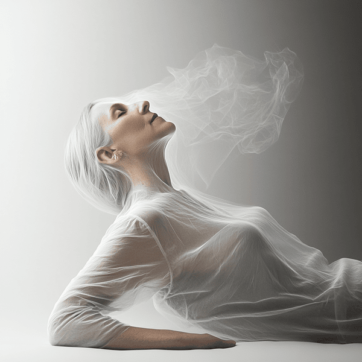

There’s a guy out there named [Darius](https://dariusjwright.com/life-altering-encounter-reveals-to-man-the-future-of-our-hologram-unseen-realms-darius-j-wright/) who seems to have a lot of these other-worldly gifts and capabilities inculcated into one physical human being. I’m not sure if he’s telekinetic. If there’s a scale of ability, what I can do compared to where he goes, I’m more like 2 or 3, Darius is running more like a 9 or 10, an amazing gift. He may disagree on my scale’s metrics but he’s definitely on to something very significant, meaningful, expansive, and worth looking into.

**So this is how ‘traveling’ happens with me:**

**In My Past:** A prerequisite is that I have to be in a calm state of mind. That is a necessity, then and now. For me this used to be when I first lay down for bed and just at that brief moment before falling asleep the imagery began.

I began to recognize that in an ultra-relaxed state with eyes closed, that my eyes might have been trying to focus on nothing - blackness. How does an eye focus on blackness? But in the blackness state there existed waves or swells of light. I first thought that my brain was recreating the last images I saw when I was still awake, but realized that the waves of light endured for an extraordinarily long time. It felt like the universe was trying to show me something I needed to see. I began to give myself over to the closed-eyes light-events, to just let it run until sleep but I was fully conscious for the most part. By staying in the light-wave events, exiguous, amorphous shapes would appear to be coming from behind me and coalesce in front of me and then zoom off into the distance. It was much like a beckoning call, an enticement, to go run with us. The more relaxed I was, the faster they coalesced and zoomed away. Giving over to that event-state, I would suddenly see the fabric of the blackness open up right in front of me like a magical theater curtain. The first time I remember being at a fountain in a public square, a lot of white marble complete with little kids playing in the water and pigeons on the ground. I’ve been many places on earth but not Italy yet as this is where I thought I was. I didn’t have a sense of what year it was either, but it was so real that I heard the people and felt wind blown droplets of water on my face but I had no sense of my corporeal body such as I couldn’t see my arms or legs, etc. One man did seem to sense me and started to walk with purpose directly towards me. He may have traveled there himself just as I did. It was so vivid, yet so unsettling that I got nervous, afraid of his attention and intention. Instantly the travelling stopped. I was back in my body in my bed in this world and timeline.

After the first true travelling experience I would allow the phenomenon to keep happening. I learned more about entering the event-state; the key was to give myself over to it. To not fight it. That knowledge is related to my near death experience where at one point, I simply let go. I began doing this so much at night that I was edging against insomnia. In one standout event-state, I found myself walking on narrow stone steps that curved around a building with walls that were made of an adobe-like construction. Again, in no body of my own that I could see. The day was sunny but with a slight reddish-orange tint to the sky. The building was occupied from what I could tell and hear but I could see no one. Walking up the steps, little niches in the wall were filled with flowers, symbols, etc., much like small religious offerings we see here. I reached a top point of the stairway where I could look over the building which I realized was comprised of many rounded domes like a honeycomb that had unusual antennae on the peaks of the small domes. It was a pretty place much like New Mexico but something was off. The shapes of the ‘antennas’ bothered me. I’d never seen antenna like those, all the same, and the vegetation really bothered me. They were weird-looking succulents and many vines with odd flowers. For whatever reason that’s all it took. I panicked, instantly I was back in my bed. My takeaway was that fear always is the destroyer of so many beautiful things, including the event-state.

> Could self-conscious awareness of fear be similar to the observer or observer-device effect that collapses the wave form in quantum superpositions at the instant of measurement? It seems so, particularly that my conscious may be in two positions or locations at the same time. It’s more than uncanny which does raise the concern that at a fear-collapse state could I, the actual me in this universe, be trapped or exchanged in my alter-consciousness somewhere else? Kinda’ makes a guy not want to sleep anymore.

I no longer need to be in a near sleep state lying in the bed. I can now close my eyes and the waves of light gather like a cloud before me one after another, I’d say every 15 seconds or so. When they get very rapid - I’m off. The differences between the first experiences and now is I’m able to stay in the event-state for far longer and I no longer fear this activity. Most of what I see now is in black and white, shades of gray, and muted colors. But most importantly I can see and experience other beings, where each one has been unique so far. I have interacted with groups of the same being type. The vast majority are faces and torsos that appear out of the blackness, observe me as I observe them, and then zoom away as fast as they arrived. It’s a lot like spirit speed dating or something. Sometimes we linger together for most of the duration of the event-state.

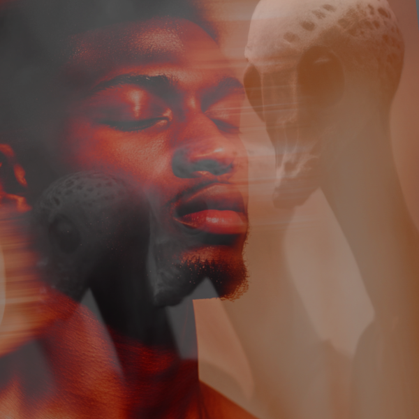

I like when that happens. The feeling is good, but not telepathic. I don’t know what they are thinking, I only know that the vibe is curious and safe. Me looking at them, them looking at me, and from that you can tell if it’s good or bad. I mentioned in another piece that not all the beings or energies (which are the more pure cloud-like entities), are of love and positive intentions.

In one travelling event-state, I found myself entering through a wall to a kitchen or lab counter area where a full-body being was preparing something on a countertop. It was a 3D lighted space like any room on earth in full color. I was above him in a corner of the room. I got the vibe that he was male. He was startled and looked directly at me which normally doesn’t immediately happen. He grabbed something off the counter and threw it directly at me as if I was a fly on the wall. I quickly left that space but remained in the same event-state, but at a different location. I re-entered that same structure through a metal door where a group of similar beings were standing in formation as if receiving orders with one in charge facing about six others. Once they realized my presence, they all came toward me with a purpose that seemed very aggressive. That’s when I panicked and it was over. These beings definitely were humanoid, tall, light in color, interesting to look at and reminiscent of MugWump in the Naked Lunch movie. No kidding.

[figure not shown]

I have since learned that If I go into an event-state without a good intention anything shows up. In this state anything truly means anything. I’m not sure that any of these beings or energies could do physical harm to me but I really don’t want to find out either. Fear in this case is a failsafe, but what am I missing to let fear in? Or am I reading these perceived negatives wrongly?

**After a good 30 years or so, the translucent light energies now come immediately at will.** Then come the beings in that order for me. It is a bit less frequent lately to travel to a distinct place, but that does still happen. When it does, I just go and experience it. I’ve asked a few people over the years if they have the same experience when going to sleep or at all. Most look at me like I’ve got 3 heads. I usually leave it at that unless they have had such an experience or are curious.

**Exit from the Woodchuck Hole - The Big Picture**

The universe has many layers or membranes or infinite dimensions. We just happen to be in one part of it, our own little membrane encompassing everything we know thus far. It may seem infinite, but it’s actually small and segmented considering all the other possibilities. We’re just now opening these doors and getting a glimpse at understanding what lies beyond the threshold. My event-states and those of others breach our human sensed constraints and opens up to many other levels of existence and consciousness. Surviving shamanic traditions and their routes have been doing and teaching this down the generations for thousands of years against the tides of cultural suppression. I wonder what has been lost to us over the eons and how long it will take to regain our abilities. The universe I know is crowded, full of many different beings, energies, and levels of existence that are intertwined. Throughout my life one of my mantras has been the connectedness of all things. Like many of you, I just feel it. To realize that one’s consciousness can collapse a quantum wave form of entangled particles such as photons and other bosons into a measurable state is like a golden ticket to the magic and wonders of the universe. Nothing will be off limits if we can grow, collectively expand in this new knowledge and wisdom, and just run with it in peace for once. You already know the rest of that message.

What I’ve described here may be spooky action at a distance on steroids. That is what has been given to me. I do enjoy it, accept it, and am happy to share it. One day I’d like to go much further and see more although I do not know what effect that would have on my physical body. A near death experience this is not though. I’ll try to share my experience and perspective on that shortly.

*If anyone reading this can relate to the ‘travelling’ out of body experience, I’d really like to hear from you in the comments or message me. Maybe we can meet up –> over there.

Thanks all for reading! Please share. Supporting this work as a Paid Subscriber or Coffee Buyer would be fantastic and greatly appreciated. It helps to enable some very special content.

[interactive chart not shown]